# Hurricanes and Volatility schocks in WTI Crude Oil and Natural Oil

This is a replication study from another students, the replication is aimed to understand more about GARCH model. This replication study just cover a part of a the original work. In this study, the Normal distribution provides a better statistical fit than the Student's-t distribution, contrasting with the original study's results. However this study show the same result with the orginal version: a positive relationship exists between hurricane effects and natural gas prices, whereas hurricanes show no impact on crude oil prices

### Research Question

**To what extent does the physical intensity of hurricanes entering the Gulf of Mexico induce volatility shocks in WTI Crude Oil and Natural Gas futures?**

### Theoretical Background

The Gulf of Mexico is a critical region for U.S. energy production:

- **~15% of U.S. crude oil production** from offshore platforms (EIA, 2024)
- **~2% of U.S. natural gas production** from federal offshore (EIA, 2024)
- **~45% of U.S. petroleum refining capacity** located along the Gulf Coast (EIA, 2024)
- Critical pipeline infrastructure and storage facilities including Henry Hub and Strategic Petroleum Reserve

**Hypothesis:** Hurricanes generate **exogenous supply shocks** that manifest as increased price volatility, even when physical damage remains limited.

### Data Source

**IBTrACS v04r01.csv**

- Temporal Coverage: 1851 - 2025
- Spatial Resolution: 3-hourly track points

### Methodology Overview

1. **Geographic Filtering:** Gulf of Mexico
2. **Intensity Variables:** USA_WIND (kts), USA_SSHS (Saffir-Simpson)
3. **Temporal Aggregation:** Daily maximum values
4. **Storm Type Differentiation:** Separate Tropical Storms from Hurricanes
5. **Output:** Clean daily hurricane exposure dataset

```python
# Import Libraries
import pandas as pd
import matplotlib.pyplot as plt
import seaborn as sns
#ignore warnings
import warnings
warnings.filterwarnings('ignore')
```

```python
# Load hurricane data
# skiprows=[1] removes the units row, keeping variable names as headers

df_raw = pd.read_csv('ibtracs.NA.list.v04r01.csv',
                     skiprows=[1],
                     low_memory=False)

print(f" Data loaded: {df_raw.shape[0]:,} observations × {df_raw.shape[1]} variables")
print(f" Time range: {df_raw['ISO_TIME'].min()} to {df_raw['ISO_TIME'].max()}")
```

```
 Data loaded: 127,495 observations × 174 variables
 Time range: 1851-06-23 12:00:00 to 2025-10-11 18:00:00
```

```python
# show all column, display max columns
pd.set_option('display.max_columns', None)
df_raw.head()
```

|  | SID | SEASON | NUMBER | BASIN | SUBBASIN | NAME | ISO_TIME | NATURE | LAT | LON | WMO_WIND | WMO_PRES | WMO_AGENCY | TRACK_TYPE | DIST2LAND | LANDFALL | IFLAG | USA_AGENCY | USA_ATCF_ID | USA_LAT | USA_LON | USA_RECORD | USA_STATUS | USA_WIND | USA_PRES | USA_SSHS | USA_R34_NE | USA_R34_SE | USA_R34_SW | … |
| --- | --- | --- | --- | --- | --- | --- | --- | --- | --- | --- | --- | --- | --- | --- | --- | --- | --- | --- | --- | --- | --- | --- | --- | --- | --- | --- | --- | --- | --- | --- |
| 0 | 1851175N26270 | 1851 | 5 | NaN | GM | UNNAMED | 1851-06-23 12:00:00 | TS | 26.1 | -90.4 |  |  |  | main | 335 | 323 | ______________O |  |  |  |  |  |  |  |  | -5 |  |  |  | … |
| 1 | 1851175N26270 | 1851 | 5 | NaN | GM | UNNAMED | 1851-06-23 15:00:00 | TS | 26.2 | -90.7 |  |  |  | main | 323 | 312 | ______________P |  |  |  |  |  |  |  |  | -5 |  |  |  | … |
| 2 | 1851175N26270 | 1851 | 5 | NaN | GM | UNNAMED | 1851-06-23 18:00:00 | TS | 26.3 | -91.0 |  |  |  | main | 312 | 302 | ______________O |  |  |  |  |  |  |  |  | -5 |  |  |  | … |
| 3 | 1851175N26270 | 1851 | 5 | NaN | GM | UNNAMED | 1851-06-23 21:00:00 | TS | 26.4 | -91.3 |  |  |  | main | 304 | 296 | ______________P |  |  |  |  |  |  |  |  | -5 |  |  |  | … |
| 4 | 1851175N26270 | 1851 | 5 | NaN | GM | UNNAMED | 1851-06-24 00:00:00 | TS | 26.5 | -91.6 |  |  |  | main | 298 | 292 | ______________O |  |  |  |  |  |  |  |  | -5 |  |  |  | … |

```python
# show column names and data types
print("\nColumn names and data types:")
print(df_raw.dtypes)
```

```
Column names and data types:
SID                str
SEASON           int64
NUMBER           int64
BASIN              str
SUBBASIN           str
                 ...
USA_SEARAD_SE      str
USA_SEARAD_SW      str
USA_SEARAD_NW      str
STORM_SPEED        str
STORM_DIR          str
Length: 174, dtype: object
```

```python
# Data Type Conversion
df_raw['ISO_TIME'] = pd.to_datetime(df_raw['ISO_TIME']) # Convert ISO_TIME to datetime format
df_raw['LAT'] = pd.to_numeric(df_raw['LAT'], errors='coerce')
df_raw['LON'] = pd.to_numeric(df_raw['LON'], errors='coerce')
df_raw['USA_WIND'] = pd.to_numeric(df_raw['USA_WIND'], errors='coerce') #USA_WIND is the maximum sustained wind speed in knots, which is a primary measure of hurricane strength. Higher values indicate stronger hurricanes.
df_raw['USA_PRES'] = pd.to_numeric(df_raw['USA_PRES'], errors='coerce') #USA_PRES is the central pressure in millibars, which is a key indicator of hurricane intensity. Lower values indicate stronger hurricanes.
df_raw['USA_SSHS'] = pd.to_numeric(df_raw['USA_SSHS'], errors='coerce') #USA_SSHS is the Saffir-Simpson Hurricane Scale category, which classifies hurricanes based on their wind speed. Higher values indicate more severe hurricanes.
df_raw['SEASON'] = pd.to_numeric(df_raw['SEASON'], errors='coerce')#SEASON is the year of the hurricane season, which allows us to analyze trends and patterns in hurricane activity over time.
```

```python
pd.set_option('display.max_columns', None)
df_raw.head()
```

|  | SID | SEASON | NUMBER | BASIN | SUBBASIN | NAME | ISO_TIME | NATURE | LAT | LON | WMO_WIND | WMO_PRES | WMO_AGENCY | TRACK_TYPE | DIST2LAND | LANDFALL | IFLAG | USA_AGENCY | USA_ATCF_ID | USA_LAT | USA_LON | USA_RECORD | USA_STATUS | USA_WIND | USA_PRES | USA_SSHS | USA_R34_NE | USA_R34_SE | USA_R34_SW | … |
| --- | --- | --- | --- | --- | --- | --- | --- | --- | --- | --- | --- | --- | --- | --- | --- | --- | --- | --- | --- | --- | --- | --- | --- | --- | --- | --- | --- | --- | --- | --- |
| 0 | 1851175N26270 | 1851 | 5 | NaN | GM | UNNAMED | 1851-06-23 12:00:00 | TS | 26.1 | -90.4 |  |  |  | main | 335 | 323 | ______________O |  |  |  |  |  |  | NaN | NaN | -5 |  |  |  | … |
| 1 | 1851175N26270 | 1851 | 5 | NaN | GM | UNNAMED | 1851-06-23 15:00:00 | TS | 26.2 | -90.7 |  |  |  | main | 323 | 312 | ______________P |  |  |  |  |  |  | NaN | NaN | -5 |  |  |  | … |
| 2 | 1851175N26270 | 1851 | 5 | NaN | GM | UNNAMED | 1851-06-23 18:00:00 | TS | 26.3 | -91.0 |  |  |  | main | 312 | 302 | ______________O |  |  |  |  |  |  | NaN | NaN | -5 |  |  |  | … |
| 3 | 1851175N26270 | 1851 | 5 | NaN | GM | UNNAMED | 1851-06-23 21:00:00 | TS | 26.4 | -91.3 |  |  |  | main | 304 | 296 | ______________P |  |  |  |  |  |  | NaN | NaN | -5 |  |  |  | … |
| 4 | 1851175N26270 | 1851 | 5 | NaN | GM | UNNAMED | 1851-06-24 00:00:00 | TS | 26.5 | -91.6 |  |  |  | main | 298 | 292 | ______________O |  |  |  |  |  |  | NaN | NaN | -5 |  |  |  | … |

```python
# Descriptive Statistics - Intensity Variables
print("\nIntensity Variables - Summary Statistics:")

print("\nUSA_WIND (Wind Speed in knots):")
print(df_raw['USA_WIND'].describe())

print("\nUSA_PRES (Central Pressure in mb):")
print(df_raw['USA_PRES'].describe())

print("\nUSA_SSHS (Saffir-Simpson Hurricane Scale):")
print(df_raw['USA_SSHS'].value_counts().sort_index())
```

```
Intensity Variables - Summary Statistics:

USA_WIND (Wind Speed in knots):
count    108355.000000
mean         52.798920
std          24.491116
min          10.000000
25%          35.000000
50%          45.000000
75%          70.000000
max         165.000000
Name: USA_WIND, dtype: float64

USA_PRES (Central Pressure in mb):
count    47400.00000
mean       992.58711
std         18.95274
min        882.00000
25%        985.00000
50%        999.00000
75%       1006.00000
max       1024.00000
Name: USA_PRES, dtype: float64

USA_SSHS (Saffir-Simpson Hurricane Scale):
USA_SSHS
-5    19128
-4    11673
-3     4423
-2     2092
-1    19835
 0    39780
 1    15695
 2     8265
 3     4042
 4     2207
 5      355
Name: count, dtype: int64
```

## 1.4 Geographic Filtering: Gulf of Mexico

### Rationale

The Gulf of Mexico is defined by:

- **Latitude:** 18.0°N - 30.0°N (from Yucatan to Louisiana/Texas coast)
- **Longitude:** -98.0°W - -80.0°W (from Texas to Florida Panhandle)

This region contains:

- Offshore oil & gas platforms
- Major U.S. refineries
- Henry Hub (natural gas pricing point)
- Strategic Petroleum Reserve sites

```python
# Define Gulf of Mexico Bounding Box
LAT_MIN, LAT_MAX = 18.0, 30.0
LON_MIN, LON_MAX = -98.0, -80.0

# Apply Geographic Filter
gulf_mask = (
    (df_raw['LAT'] >= LAT_MIN) &
    (df_raw['LAT'] <= LAT_MAX) &
    (df_raw['LON'] >= LON_MIN) &
    (df_raw['LON'] <= LON_MAX)
)

df_gulf = df_raw[gulf_mask].copy()

print("Gulf of Mexico Filter Results:")
print("="*60)
print(f"  Total observations (all Atlantic): {len(df_raw):,}")
print(f"  Gulf observations:                 {len(df_gulf):,}")
print(f"  Percentage in Gulf:                {len(df_gulf)/len(df_raw)*100:.2f}%")
print(f"\n  Unique storms (all Atlantic):      {df_raw['SID'].nunique():,}")
print(f"  Unique storms in Gulf:             {df_gulf['SID'].nunique():,}")
```

```
Gulf of Mexico Filter Results:
============================================================
  Total observations (all Atlantic): 127,495
  Gulf observations:                 20,659
  Percentage in Gulf:                16.20%

  Unique storms (all Atlantic):      2,315
  Unique storms in Gulf:             870
```

```python
# Temporal Distribution of Gulf Storms
storms_per_year = df_gulf.groupby('SEASON')['SID'].nunique()

print("\nGulf Storm Activity Over Time:")
print("="*60)
print(f"  Years with Gulf activity:  {len(storms_per_year)}")
print(f"  Average storms/year:       {storms_per_year.mean():.1f}")
print(f"  Min/Max storms/year:       {storms_per_year.min()} / {storms_per_year.max()}")
print(f"  Std deviation:             {storms_per_year.std():.1f}")
```

```
Gulf Storm Activity Over Time:
============================================================
  Years with Gulf activity:  175
  Average storms/year:       5.0
  Min/Max storms/year:       1 / 13
  Std deviation:             2.5
```

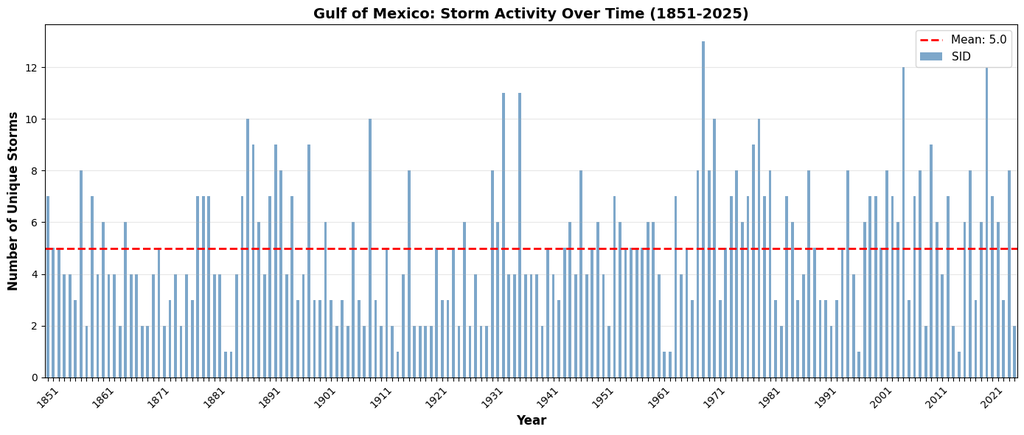

```python
# Visualization: Gulf Storms Per Year
fig, ax = plt.subplots(figsize=(14, 6))

storms_per_year.plot(kind='bar', ax=ax, color='steelblue', alpha=0.7)
ax.axhline(storms_per_year.mean(), color='red', linestyle='--',
           label=f'Mean: {storms_per_year.mean():.1f}', linewidth=2)

ax.set_xlabel('Year', fontsize=12, fontweight='bold')
ax.set_ylabel('Number of Unique Storms', fontsize=12, fontweight='bold')
ax.set_title('Gulf of Mexico: Storm Activity Over Time (1851-2025)',
             fontsize=14, fontweight='bold')
ax.legend(fontsize=11)
ax.grid(axis='y', alpha=0.3)

# Show only every 10th year on x-axis for readability
ticks = ax.get_xticks()
labels = [storms_per_year.index[int(t)] if t % 10 == 0 and int(t) < len(storms_per_year)
          else '' for t in ticks]
ax.set_xticklabels(labels, rotation=45)

plt.tight_layout()
plt.show()
```

## 1.5 Intensity Variable Construction

### Primary Intensity Measure: USA_WIND

- **Definition:** Maximum sustained wind speed in knots
- **Rationale:**
  - Continuous variable (better for regression)
  - Highly correlated with infrastructure damage

### Secondary Intensity Measure: USA_SSHS

- **Definition:** Saffir-Simpson Hurricane Scale (categorical)
- **Categories:**
  - -5 to -1: Pre-tropical stages
  - 0: Tropical Depression (TD) or Tropical Storm (TS) below hurricane threshold
  - 1-5: Hurricane categories (≥64 kts)
- **Rationale:**
  - Standardized, policy-relevant metric
  - Captures non-linear damage functions
  - Robustness check for continuous measure

```python
# Filter for non-missing intensity data
df_gulf_clean = df_gulf[
    df_gulf['USA_WIND'].notna() &
    df_gulf['USA_SSHS'].notna()
].copy()

print("Data Quality After Intensity Filters:")
print("="*60)
print(f"  Observations before:  {len(df_gulf):,}")
print(f"  Observations after:   {len(df_gulf_clean):,}")
print(f"  Data loss:            {(1 - len(df_gulf_clean)/len(df_gulf))*100:.2f}%")

# Analyze data loss by time period
print("\n" + "="*60)
print("DATA LOSS ANALYSIS BY TIME PERIOD")
print("="*60)

df_gulf_clean['year'] = df_gulf_clean['SEASON']
df_gulf['year'] = df_gulf['SEASON']

# Split by period: before 2000 vs. after 2000
df_gulf_pre2000 = df_gulf[df_gulf['year'] < 2000]
df_gulf_post2000 = df_gulf[df_gulf['year'] >= 2000]

df_clean_pre2000 = df_gulf_clean[df_gulf_clean['year'] < 2000]
df_clean_post2000 = df_gulf_clean[df_gulf_clean['year'] >= 2000]

# Calculate losses
loss_pre2000 = len(df_gulf_pre2000) - len(df_clean_pre2000)
loss_post2000 = len(df_gulf_post2000) - len(df_clean_post2000)
total_loss = len(df_gulf) - len(df_gulf_clean)

print(f"\nPre-2000 (before year 2000):")
print(f"  Original observations:  {len(df_gulf_pre2000):,}")
print(f"  After filtering:        {len(df_clean_pre2000):,}")
print(f"  Data loss:              {loss_pre2000:,} ({loss_pre2000/len(df_gulf_pre2000)*100:.2f}%)")

print(f"\nPost-2000 (year 2000 onwards):")
print(f"  Original observations:  {len(df_gulf_post2000):,}")
print(f"  After filtering:        {len(df_clean_post2000):,}")
print(f"  Data loss:              {loss_post2000:,} ({loss_post2000/len(df_gulf_post2000)*100:.2f}%)")

print(f"\nTotal Data Loss Breakdown:")
print(f"  Total lost:             {total_loss:,}")
print(f"  Lost from pre-2000:     {loss_pre2000:,} ({loss_pre2000/total_loss*100:.2f}% of total loss)")
print(f"  Lost from post-2000:    {loss_post2000:,} ({loss_post2000/total_loss*100:.2f}% of total loss)")

print("\n All the data loss due to missing intensity values is before year 2000.")
```

```
Data Quality After Intensity Filters:
============================================================
  Observations before:  20,659
  Observations after:   18,431
  Data loss:            10.78%

============================================================
DATA LOSS ANALYSIS BY TIME PERIOD
============================================================

Pre-2000 (before year 2000):
  Original observations:  17,215
  After filtering:        14,987
  Data loss:              2,228 (12.94%)

Post-2000 (year 2000 onwards):
  Original observations:  3,444
  After filtering:        3,444
  Data loss:              0 (0.00%)

Total Data Loss Breakdown:
  Total lost:             2,228
  Lost from pre-2000:     2,228 (100.00% of total loss)
  Lost from post-2000:    0 (0.00% of total loss)

 All the data loss due to missing intensity values is before year 2000.
```

## 1.6 Temporal Aggregation to Daily Frequency

### Rationale for Daily Maximum

the data provides sub-daily observations (3 hourly), but financial market data is daily. We aggregate using the **maximum intensity per day** because:

1. **Worst-Case Logic:** Markets respond to peak risk exposure, not average conditions
2. **Asymmetric Impact:** One intense event > multiple weak events (non-linear damage)
3. **Conservative Approach:** Preserves extreme events that drive volatility spikes

### Aggregation Procedure

For each calendar date, we extract:

- `hurricane_wind_max`: Maximum wind speed across all track points in Gulf
- `hurricane_category_max`: Maximum USA_SSHS category
- `n_storms`: Number of distinct storms in Gulf on that day

```python
# Create Date column (without time)
df_gulf_clean['date'] = df_gulf_clean['ISO_TIME'].dt.date
df_gulf_clean['date'] = pd.to_datetime(df_gulf_clean['date'])

# Daily Aggregation
df_daily = df_gulf_clean.groupby('date').agg({
    'USA_WIND': 'max',           # Maximum wind speed
    'USA_SSHS': 'max',           # Maximum category
    'SID': ['nunique', 'count']  # Number of unique storms & observations
}).reset_index()

# Flatten column names
df_daily.columns = ['date', 'hurricane_wind_max', 'hurricane_category_max',
                    'n_storms', 'n_observations']

print("Daily Aggregated Dataset:")
print("="*60)
print(f"  Date range:          {df_daily['date'].min()} to {df_daily['date'].max()}")
print(f"  Total days with Gulf storms: {len(df_daily):,}")
print(f"  Average wind:          {df_daily['hurricane_wind_max'].mean():.1f} kts")
print(f"  Average category:      {df_daily['hurricane_category_max'].mean():.2f}")

# Display sample
print("\nSample of Daily Dataset:")
print(df_daily.head(10))
```

```
Daily Aggregated Dataset:
============================================================
  Date range:          1851-06-25 00:00:00 to 2025-07-04 00:00:00
  Total days with Gulf storms: 2,902
  Average wind:          57.1 kts
  Average category:      0.40

Sample of Daily Dataset:
        date  hurricane_wind_max  hurricane_category_max  n_storms  \
0 1851-06-25                80.0                       1         1
1 1851-06-26                70.0                       1         1
2 1851-07-05                80.0                       1         1
3 1851-08-20                65.0                       1         1
4 1851-08-21                75.0                       1         1
5 1851-08-22                95.0                       2         1
6 1851-08-23               100.0                       3         1
7 1852-08-22                90.0                       2         1
8 1852-08-23                95.0                       2         1
9 1852-08-24               100.0                       3         1

   n_observations
0               8
1               4
2               1
3               1
4               8
5               8
6               8
7               6
8               8
9               8
```

## 1.7 Quality Checks & Validation

```python
# Check for data integrity issues
print("Data Integrity Checks:")
print("="*60)

#  Missing values in key variables
print("\n Missing Values:")
print(df_daily[['hurricane_wind_max', 'hurricane_category_max', 'n_storms']].isnull().sum())
```

```
Data Integrity Checks:
============================================================

 Missing Values:
hurricane_wind_max        0
hurricane_category_max    0
n_storms                  0
dtype: int64
```

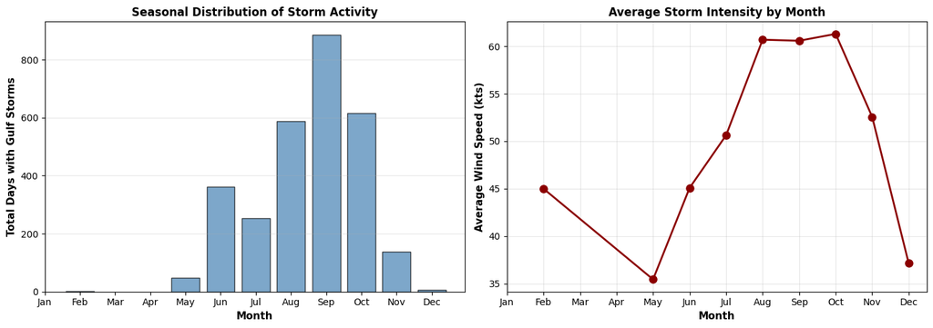

```python
# Seasonal Pattern Analysis
df_daily['month'] = df_daily['date'].dt.month

monthly_activity = df_daily.groupby('month').agg({
    'hurricane_wind_max': ['count', 'mean']
}).reset_index()
monthly_activity.columns = ['month', 'n_days', 'avg_wind']

fig, axes = plt.subplots(1, 2, figsize=(14, 5))

# Days with storms by month
axes[0].bar(monthly_activity['month'], monthly_activity['n_days'],
            color='steelblue', alpha=0.7, edgecolor='black')
axes[0].set_xlabel('Month', fontsize=11, fontweight='bold')
axes[0].set_ylabel('Total Days with Gulf Storms', fontsize=11, fontweight='bold')
axes[0].set_title('Seasonal Distribution of Storm Activity', fontsize=12, fontweight='bold')
axes[0].set_xticks(range(1, 13))
axes[0].set_xticklabels(['Jan', 'Feb', 'Mar', 'Apr', 'May', 'Jun',
                         'Jul', 'Aug', 'Sep', 'Oct', 'Nov', 'Dec'])
axes[0].grid(axis='y', alpha=0.3)

# Average intensity by month
axes[1].plot(monthly_activity['month'], monthly_activity['avg_wind'],
             marker='o', linewidth=2, markersize=8, color='darkred')
axes[1].set_xlabel('Month', fontsize=11, fontweight='bold')
axes[1].set_ylabel('Average Wind Speed (kts)', fontsize=11, fontweight='bold')
axes[1].set_title('Average Storm Intensity by Month', fontsize=12, fontweight='bold')
axes[1].set_xticks(range(1, 13))
axes[1].set_xticklabels(['Jan', 'Feb', 'Mar', 'Apr', 'May', 'Jun',
                         'Jul', 'Aug', 'Sep', 'Oct', 'Nov', 'Dec'])
axes[1].grid(alpha=0.3)

plt.tight_layout()
plt.show()
```

## 1.8 Creating Differentiated Storm Variables

### New Variable Definitions

We create **three separate binary indicators**:

1. **`tropical_storm_in_gulf`**: Tropical Storm/Depression ONLY (wind < 64 kt)
   - Use case: Isolate weak storms for sensitivity analysis
2. **`hurricane_in_gulf`**: hurricane (wind ≥ 64 kt, Cat 1-5)
   - **PRIMARY treatment variable for causal analysis**
   - Use case: Measure impact of infrastructure-threatening events
3. **`hurricane_category`**:
- 0 for all non-hurricanes (wind < 64 kt)
- 1-5 for true hurricane categories

```python
# CREATE DIFFERENTIATED STORM VARIABLES
# Start with daily aggregated data
df_new = df_daily.copy()

# 1. Any storm in Gulf (includes ALL tropical cyclones: TD, TS, H)
df_new['any_storm_in_gulf'] = 1  # Already filtered to Gulf, so all days = 1

# 2. Tropical Storm/Depression indicator (wind < 64 kt)
df_new['tropical_storm_in_gulf'] = (df_new['hurricane_wind_max'] < 64).astype(int)

# 3. Hurricane indicator (wind ≥ 64 kt, Categories 1-5)
df_new['hurricane_in_gulf'] = (df_new['hurricane_wind_max'] >= 64).astype(int)

#4. Category variable
# Set to 0 for non-hurricanes, preserve 1-5 for hurricanes
df_new['hurricane_category'] = df_new['hurricane_category_max'].copy()
df_new.loc[df_new['hurricane_wind_max'] < 64, 'hurricane_category'] = 0


# Summary statistics
print("\n" + "="*70)
print("SUMMARY: Storm Type Frequency")
print("="*70)
total = len(df_new)
n_any_storm = df_new['any_storm_in_gulf'].sum()
n_tropical_storm = df_new['tropical_storm_in_gulf'].sum()
n_hurricane = df_new['hurricane_in_gulf'].sum()

print(f"\n  Total days with ANY storm in Gulf:          {n_any_storm:4d} (100.0%)")
print(f"    - Days with Tropical Storm/Depression:    {n_tropical_storm:4d} ({n_tropical_storm/total*100:5.1f}%)")
print(f"    - Days with  Hurricane:                   {n_hurricane:4d} ({n_hurricane/total*100:5.1f}%)")

print("="*70)
```

```
======================================================================
SUMMARY: Storm Type Frequency
======================================================================

  Total days with ANY storm in Gulf:          2902 (100.0%)
    - Days with Tropical Storm/Depression:    1914 ( 66.0%)
    - Days with  Hurricane:                    988 ( 34.0%)
======================================================================
```

## 1.10 Export Dataset

### Final Output Variables

**Intensity Measures:**

- `date`: Calendar date (YYYY-MM-DD)
- `hurricane_wind_max`: Maximum wind speed in Gulf on that day (knots)
- `hurricane_category_max`: Original USA_SSHS (preserved for reference)
- `hurricane_category`: 0 for non-hurricanes, 1-5 for hurricanes
- `n_storms`: Number of distinct storms in Gulf

**Differentiated Storm Indicators :**

- `any_storm_in_gulf`: 1 if ANY tropical cyclone present
- `tropical_storm_in_gulf`: 1 if Tropical Storm/Depression (wind < 64 kt)
- `hurricane_in_gulf`: **1 if TRUE hurricane (wind ≥ 64 kt)**

```python
# SELECT FINAL VARIABLES FOR EXPORT
df_final = df_new[[
    'date',
    'hurricane_wind_max',
    'hurricane_category_max',           # Original (for reference)
    'hurricane_category',               #  0 for non-hurricanes
    'n_storms',
    'any_storm_in_gulf',                # All tropical cyclones
    'tropical_storm_in_gulf',           # Weak storms (< 64 kt)
    'hurricane_in_gulf'                 # hurricanes (≥ 64 kt)
]].copy()

# Sort by date
df_final = df_final.sort_values('date').reset_index(drop=True)

# Save corrected dataset
output_path = 'hurricane_daily_clean.csv'
df_final.to_csv(output_path, index=False)

print("="*70)
print("Hurricane Dataset:")
print("="*70)
print(f"\n  File:          {output_path}")
print(f"  Rows:          {len(df_final):,}")
print(f"  Columns:       {len(df_final.columns)}")
print(f"  Date range:    {df_final['date'].min()} to {df_final['date'].max()}")

print("\n" + "-"*70)
print("Variable Summary:")
print("-"*70)
print(f"  Days with ANY storm:           {df_final['any_storm_in_gulf'].sum():,}")
print(f"  Days with Tropical Storm only: {df_final['tropical_storm_in_gulf'].sum():,}")
print(f"  Days with Hurricane:           {df_final['hurricane_in_gulf'].sum():,}")

# Display sample with new variables
print("\nSample of the Dataset:")
print(df_final.head(15).to_string(index=False))
```

```
======================================================================
Hurricane Dataset:
======================================================================

  File:          hurricane_daily_clean.csv
  Rows:          2,902
  Columns:       8
  Date range:    1851-06-25 00:00:00 to 2025-07-04 00:00:00

----------------------------------------------------------------------
Variable Summary:
----------------------------------------------------------------------
  Days with ANY storm:           2,902
  Days with Tropical Storm only: 1,914
  Days with Hurricane:           988

Sample of the Dataset:
      date  hurricane_wind_max  hurricane_category_max  hurricane_category  n_storms  any_storm_in_gulf  tropical_storm_in_gulf  hurricane_in_gulf
1851-06-25                80.0                       1                   1         1                  1                       0                  1
1851-06-26                70.0                       1                   1         1                  1                       0                  1
1851-07-05                80.0                       1                   1         1                  1                       0                  1
1851-08-20                65.0                       1                   1         1                  1                       0                  1
1851-08-21                75.0                       1                   1         1                  1                       0                  1
1851-08-22                95.0                       2                   2         1                  1                       0                  1
1851-08-23               100.0                       3                   3         1                  1                       0                  1
1852-08-22                90.0                       2                   2         1                  1                       0                  1
1852-08-23                95.0                       2                   2         1                  1                       0                  1
1852-08-24               100.0                       3                   3         1                  1                       0                  1
1852-08-25               100.0                       3                   3         1                  1                       0                  1
1852-08-26               100.0                       3                   3         1                  1                       0                  1
1852-09-09                70.0                       1                   1         1                  1                       0                  1
1852-09-10                70.0                       1                   1         1                  1                       0                  1
1852-09-11                70.0                       1                   1         1                  1                       0                  1
```

# Commodity Data

### Objective

Download and prepare daily Close prices for WTI Crude Oil and Natural Gas futures contracts to analyze hurricane-induced volatility spillovers.

### Data Source

**Yahoo Finance API** via `yfinance` Python library

- Tickers: `CL=F` (WTI Continuous), `NG=F` (Natural Gas Continuous)
- Frequency: Daily
- Variable: Close Price
- Coverage: ~2000 onwards (data before 2000 not availble)

### Methodology

```python
# Import Libraries
import yfinance as yf
import pandas as pd
import numpy as np
import matplotlib.pyplot as plt
from datetime import datetime
```

```python
# crude oil price data
crude = yf.download('CL=F', start='1851-01-01', end='2025-12-31')
crude.head()
```

```
[*********************100%***********************]  1 of 1 completed
```

| Price Ticker Date | Close CL=F | High CL=F | Low CL=F | Open CL=F | Volume CL=F |
| --- | --- | --- | --- | --- | --- |
| 2000-08-23 | 32.049999 | 32.799999 | 31.950001 | 31.950001 | 79385 |
| 2000-08-24 | 31.629999 | 32.240002 | 31.400000 | 31.900000 | 72978 |
| 2000-08-25 | 32.049999 | 32.099998 | 31.320000 | 31.700001 | 44601 |
| 2000-08-28 | 32.869999 | 32.919998 | 31.860001 | 32.040001 | 46770 |
| 2000-08-29 | 32.720001 | 33.029999 | 32.560001 | 32.820000 | 49131 |

```python
# reset index to have date as a column
crude.reset_index(inplace=True)
crude.head()
```

| Price Ticker | Date | Close CL=F | High CL=F | Low CL=F | Open CL=F | Volume CL=F |
| --- | --- | --- | --- | --- | --- | --- |
| 0 | 2000-08-23 | 32.049999 | 32.799999 | 31.950001 | 31.950001 | 79385 |
| 1 | 2000-08-24 | 31.629999 | 32.240002 | 31.400000 | 31.900000 | 72978 |
| 2 | 2000-08-25 | 32.049999 | 32.099998 | 31.320000 | 31.700001 | 44601 |
| 3 | 2000-08-28 | 32.869999 | 32.919998 | 31.860001 | 32.040001 | 46770 |
| 4 | 2000-08-29 | 32.720001 | 33.029999 | 32.560001 | 32.820000 | 49131 |

```python
# Clean up crude oil data
# Keep only date and closing price
df_wti = crude[['Date', 'Close']].copy()
df_wti.rename(columns={'Date': 'date', 'Close': 'wti_price'}, inplace=True)
df_wti.head()
```

| Price Ticker | date | wti_price CL=F |
| --- | --- | --- |
| 0 | 2000-08-23 | 32.049999 |
| 1 | 2000-08-24 | 31.629999 |
| 2 | 2000-08-25 | 32.049999 |
| 3 | 2000-08-28 | 32.869999 |
| 4 | 2000-08-29 | 32.720001 |

```python
print(f"  Date range:    {df_wti['date'].min()} to {df_wti['date'].max()}")
```

```
  Date range:    2000-08-23 00:00:00 to 2025-12-30 00:00:00
```

```python
# Do the same for natural gas (NG=F)
ng = yf.download('NG=F', start='1851-01-01', end='2025-12-31')
ng.reset_index(inplace=True)
df_ng = ng[['Date', 'Close']].copy()
df_ng.rename(columns={'Date': 'date', 'Close': 'ng_price'}, inplace=True)
print(f"  Date range:    {df_ng['date'].min()} to {df_ng['date'].max()}")

# Drop the bottom levels and keep only the main column names
df_wti.columns = df_wti.columns.get_level_values(0)
df_ng.columns = df_ng.columns.get_level_values(0)
df_ng.head()
```

```
[*********************100%***********************]  1 of 1 completed
```

```
  Date range:    2000-08-30 00:00:00 to 2025-12-30 00:00:00
```

| Price | date | ng_price |
| --- | --- | --- |
| 0 | 2000-08-30 | 4.805 |
| 1 | 2000-08-31 | 4.780 |
| 2 | 2000-09-01 | 4.835 |
| 3 | 2000-09-05 | 4.960 |
| 4 | 2000-09-06 | 5.065 |

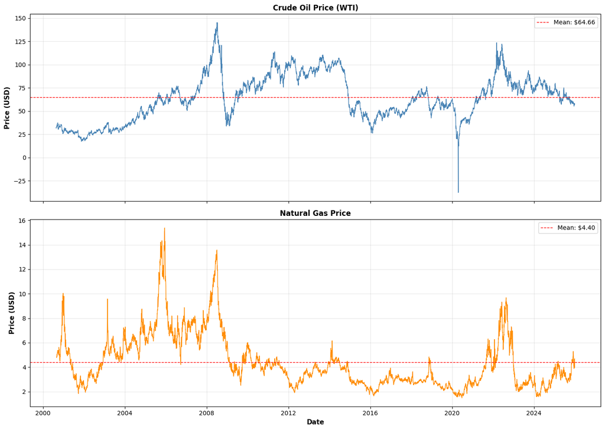

```python
import matplotlib.pyplot as plt

# 1. Calculate the scalar mean values first to avoid f-string confusion
wti_mean = df_wti['wti_price'].mean()
ng_mean = df_ng['ng_price'].mean()

# 2. Setup the subplots
fig, axes = plt.subplots(2, 1, figsize=(14, 10), sharex=True)

# Crude oil price plot
axes[0].plot(df_wti['date'], df_wti['wti_price'], color='steelblue', linewidth=1)
axes[0].set_title('Crude Oil Price (WTI)', fontsize=12, fontweight='bold')
axes[0].set_ylabel('Price (USD)', fontsize=11, fontweight='bold')
axes[0].grid(alpha=0.3)

# Natural gas price plot
axes[1].plot(df_ng['date'], df_ng['ng_price'], color='darkorange', linewidth=1)
axes[1].set_title('Natural Gas Price', fontsize=12, fontweight='bold')
axes[1].set_xlabel('Date', fontsize=11, fontweight='bold')
axes[1].set_ylabel('Price (USD)', fontsize=11, fontweight='bold')
axes[1].grid(alpha=0.3)
# add mean lines and legends
axes[0].axhline(wti_mean, color='red', linestyle='--', label=f'Mean: ${wti_mean:.2f}', linewidth=1)
axes[0].legend(fontsize=10)
axes[1].axhline(ng_mean, color='red', linestyle='--', label=f'Mean: ${ng_mean:.2f}', linewidth=1)
axes[1].legend(fontsize=10)
# Adjust padding automatically and save the figure
plt.tight_layout()
```

```python
# describe wti_price
df_wti.describe()
```

| Price | date | wti_price |
| --- | --- | --- |
| count | 6366 | 6366.000000 |
| mean | 2013-05-04 01:12:23 | 64.664978 |
| min | 2000-08-23 00:00:00 | -37.630001 |
| 25% | 2007-01-09 06:00:00 | 46.312501 |
| 50% | 2013-05-06 12:00:00 | 63.674999 |
| 75% | 2019-09-03 18:00:00 | 81.930000 |
| max | 2025-12-30 00:00:00 | 145.289993 |
| std | NaN | 24.587920 |

```python
df_ng.describe()
```

| Price | date | ng_price |
| --- | --- | --- |
| count | 6363 | 6363.000000 |
| mean | 2013-05-07 16:13:07 | 4.396129 |
| min | 2000-08-30 00:00:00 | 1.482000 |
| 25% | 2007-01-14 00:00:00 | 2.797000 |
| 50% | 2013-05-09 00:00:00 | 3.757000 |
| 75% | 2019-09-05 12:00:00 | 5.507500 |
| max | 2025-12-30 00:00:00 | 15.378000 |
| std | NaN | 2.204563 |

```python
df_wti.head()
```

| Price | date | wti_price |
| --- | --- | --- |
| 0 | 2000-08-23 | 32.049999 |
| 1 | 2000-08-24 | 31.629999 |
| 2 | 2000-08-25 | 32.049999 |
| 3 | 2000-08-28 | 32.869999 |
| 4 | 2000-08-29 | 32.720001 |

```python
# create log returns for both WTI and NG and remove nan
df_wti['wti_return'] = np.log(df_wti['wti_price'] / df_wti['wti_price'].shift(1))
df_ng['ng_return'] = np.log(df_ng['ng_price'] / df_ng['ng_price'].shift(1))
# romove the first row with NaN returns
df_wti.dropna(subset=['wti_return'], inplace=True)
df_ng.dropna(subset=['ng_return'], inplace=True)
```

```python
df_wti.head()
```

| Price | date | wti_price | wti_return |
| --- | --- | --- | --- |
| 1 | 2000-08-24 | 31.629999 | -0.013191 |
| 2 | 2000-08-25 | 32.049999 | 0.013191 |
| 3 | 2000-08-28 | 32.869999 | 0.025263 |
| 4 | 2000-08-29 | 32.720001 | -0.004574 |
| 5 | 2000-08-30 | 33.400002 | 0.020569 |

```python
df_wti['wti_return'].describe()
```

```
count    6363.000000
mean        0.000188
std         0.025804
min        -0.282206
25%        -0.012745
50%         0.001035
75%         0.013320
max         0.319634
Name: wti_return, dtype: float64
```

```python
print("Log-Returns:")
print("="*70)
print(f"\nWTI Crude Oil:")
print(f"  Valid returns: {len(df_wti):,}")
print(f"  Date range:    {df_wti['date'].min()} to {df_wti['date'].max()}")

print(f"\nNatural Gas:")
print(f"  Valid returns: {len(df_ng):,}")
print(f"  Date range:    {df_ng['date'].min()} to {df_ng['date'].max()}")
```

```
Log-Returns:
======================================================================

WTI Crude Oil:
  Valid returns: 6,363
  Date range:    2000-08-24 00:00:00 to 2025-12-30 00:00:00

Natural Gas:
  Valid returns: 6,362
  Date range:    2000-08-31 00:00:00 to 2025-12-30 00:00:00
```

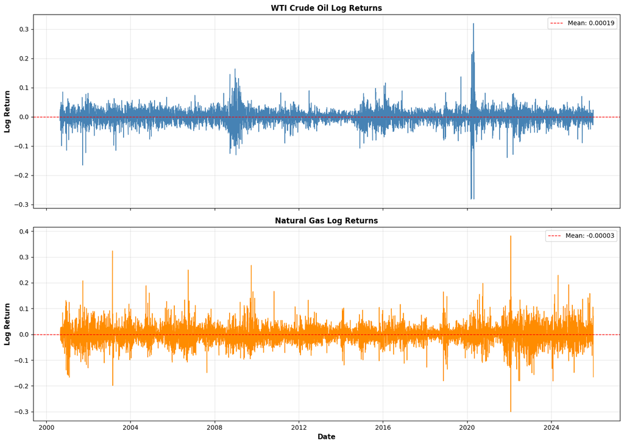

```python
#plot log returns
fig, axes = plt.subplots(2, 1, figsize=(14, 10), sharex=True)
# WTI log returns
axes[0].plot(df_wti['date'], df_wti['wti_return'], color='steelblue', linewidth=1)
axes[0].set_title('WTI Crude Oil Log Returns', fontsize=12, fontweight='bold')
axes[0].set_ylabel('Log Return', fontsize=11, fontweight='bold')
axes[0].grid(alpha=0.3)
# Natural gas log returns
axes[1].plot(df_ng['date'], df_ng['ng_return'], color='darkorange', linewidth=1)
axes[1].set_title('Natural Gas Log Returns', fontsize=12, fontweight='bold')
axes[1].set_xlabel('Date', fontsize=11, fontweight='bold')
axes[1].set_ylabel('Log Return', fontsize=11, fontweight='bold')
axes[1].grid(alpha=0.3)
# add mean lines and legends
axes[0].axhline(df_wti['wti_return'].mean(), color='red', linestyle='--', label=f'Mean: {df_wti["wti_return"].mean():.5f}', linewidth=1)
axes[0].legend(fontsize=10)
axes[1].axhline(df_ng['ng_return'].mean(), color='red', linestyle='--', label=f'Mean: {df_ng["ng_return"].mean():.5f}', linewidth=1)
axes[1].legend(fontsize=10)
plt.tight_layout()
```

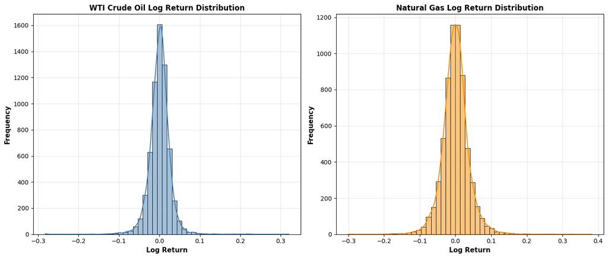

```python
#PLOT THE DISTRIBUTION OF LOG RETURNS VS NORMAL DISTRIBUTION
fig, axes = plt.subplots(1, 2, figsize=(14, 6))
sns.histplot(df_wti['wti_return'], bins=50, kde=True, ax=axes[0], color='steelblue')
axes[0].set_title('WTI Crude Oil Log Return Distribution', fontsize=12, fontweight='bold')
axes[0].set_xlabel('Log Return', fontsize=11, fontweight='bold')
axes[0].set_ylabel('Frequency', fontsize=11, fontweight='bold')
axes[0].grid(alpha=0.3)
sns.histplot(df_ng['ng_return'], bins=50, kde=True, ax=axes[1], color='darkorange')
axes[1].set_title('Natural Gas Log Return Distribution', fontsize=12, fontweight='bold')
axes[1].set_xlabel('Log Return', fontsize=11, fontweight='bold')
axes[1].set_ylabel('Frequency', fontsize=11, fontweight='bold')
axes[1].grid(alpha=0.3)
plt.tight_layout()
```

### Expected Properties of Financial Returns

1. **Mean ≈ 0:** No systematic drift in short-term returns
2. **Volatility Clustering:** Periods of high/low volatility
3. **Fat Tails:** Kurtosis > 3 (more extreme events than normal distribution)
4. **Slight Negative Skewness:** Crashes are sharper than rallies

```python
# Descriptive Statistics Function
def descriptive_stats(returns, name):
    from scipy import stats

    n = len(returns)
    mean = returns.mean()
    std = returns.std()
    skew = returns.skew()
    kurt = returns.kurtosis()
    minimum = returns.min()
    maximum = returns.max()

    # Jarque-Bera test for normality
    jb_stat, jb_pval = stats.jarque_bera(returns.dropna())

    print(f"\n{name}:")
    print("="*70)
    print(f"  Observations:      {n:,}")
    print(f"  Mean:              {mean:.4f}%")
    print(f"  Std Deviation:     {std:.4f}%")
    print(f"  Min:               {minimum:.4f}%")
    print(f"  Max:               {maximum:.4f}%")
    print(f"  Skewness:          {skew:.4f}")
    print(f"  Excess Kurtosis:   {kurt:.4f}")
    print(f"  Jarque-Bera:       {jb_stat:.2f} (p-value: {jb_pval:.4e})")

    if jb_pval < 0.01:
        print("  -> Reject normality")

    return {
        'n': n, 'mean': mean, 'std': std, 'skew': skew, 'kurt': kurt,
        'min': minimum, 'max': maximum, 'jb': jb_stat, 'jb_pval': jb_pval
    }

# Calculate for both series
stats_wti = descriptive_stats(df_wti['wti_return'], "WTI Crude Oil Returns")
stats_ng = descriptive_stats(df_ng['ng_return'], "Natural Gas Returns")
```

```
WTI Crude Oil Returns:
======================================================================
  Observations:      6,363
  Mean:              0.0002%
  Std Deviation:     0.0258%
  Min:               -0.2822%
  Max:               0.3196%
  Skewness:          -0.0317
  Excess Kurtosis:   16.3567
  Jarque-Bera:       70813.60 (p-value: 0.0000e+00)
  -> Reject normality

Natural Gas Returns:
======================================================================
  Observations:      6,362
  Mean:              -0.0000%
  Std Deviation:     0.0373%
  Min:               -0.3005%
  Max:               0.3817%
  Skewness:          0.4174
  Excess Kurtosis:   6.3004
  Jarque-Bera:       10687.46 (p-value: 0.0000e+00)
  -> Reject normality
```

# Stationary Test

```python
# stationarity test (ADF test)
from statsmodels.tsa.stattools import adfuller
adf_wti = adfuller(df_wti['wti_return'].dropna())
adf_ng = adfuller(df_ng['ng_return'].dropna())
adf_results = pd.DataFrame({
    'Series': ['WTI Crude Oil Returns', 'Natural Gas Returns'],
    'ADF Statistic': [adf_wti[0], adf_ng[0]],
    'p-value': [adf_wti[1], adf_ng[1]],
    'Critical Value (1%)': [adf_wti[4]['1%'], adf_ng[4]['1%']],
    'Critical Value (5%)': [adf_wti[4]['5%'], adf_ng[4]['5%']],
    'Critical Value (10%)': [adf_wti[4]['10%'], adf_ng[4]['10%']]
})
print("\nADF Test Results:")
print("="*70)
print(adf_results.to_string(index=False))
# stationarity conclusion
print("\nStationarity Conclusion:")
for i, row in adf_results.iterrows():
    if row['p-value'] < 0.01:
        print(f"  {row['Series']}: Reject null hypothesis -> Stationary")
    else:
        print(f"  {row['Series']}: Fail to reject null hypothesis -> Non-stationary")
```

```
ADF Test Results:
======================================================================
               Series  ADF Statistic      p-value  Critical Value (1%)  Critical Value (5%)  Critical Value (10%)
WTI Crude Oil Returns     -14.446704 7.209706e-27            -3.431382            -2.861996             -2.567013
  Natural Gas Returns     -37.403141 0.000000e+00            -3.431379            -2.861995             -2.567012

Stationarity Conclusion:
  WTI Crude Oil Returns: Reject null hypothesis -> Stationary
  Natural Gas Returns: Reject null hypothesis -> Stationary
```

```python
#merge wti with natural gas
df_commodity = pd.merge(df_wti, df_ng, on='date', how='inner')
df_commodity.head()
```

| Price | date | wti_price | wti_return | ng_price | ng_return |
| --- | --- | --- | --- | --- | --- |
| 0 | 2000-08-31 | 33.099998 | -0.009023 | 4.780 | -0.005216 |
| 1 | 2000-09-01 | 33.380001 | 0.008424 | 4.835 | 0.011441 |
| 2 | 2000-09-05 | 33.799999 | 0.012504 | 4.960 | 0.025525 |
| 3 | 2000-09-06 | 34.950001 | 0.033458 | 5.065 | 0.020948 |
| 4 | 2000-09-07 | 35.330002 | 0.010814 | 4.998 | -0.013316 |

```python
# commodity left join with hurricane data
df_commodity_hurricane = pd.merge(df_commodity,df_final, on='date', how='left')
df_commodity_hurricane.head()
df_commodity_hurricane.info()
```

```
<class 'pandas.DataFrame'>
RangeIndex: 6358 entries, 0 to 6357
Data columns (total 12 columns):
 #   Column                  Non-Null Count  Dtype
---  ------                  --------------  -----
 0   date                    6358 non-null   datetime64[s]
 1   wti_price               6358 non-null   float64
 2   wti_return              6358 non-null   float64
 3   ng_price                6358 non-null   float64
 4   ng_return               6358 non-null   float64
 5   hurricane_wind_max      378 non-null    float64
 6   hurricane_category_max  378 non-null    float64
 7   hurricane_category      378 non-null    float64
 8   n_storms                378 non-null    float64
 9   any_storm_in_gulf       378 non-null    float64
 10  tropical_storm_in_gulf  378 non-null    float64
 11  hurricane_in_gulf       378 non-null    float64
dtypes: datetime64[s](1), float64(11)
memory usage: 596.2 KB
```

```python
#replace NaN in hurricane variables with 0 (no storm)
hurricane_cols = ['hurricane_wind_max', 'hurricane_category_max', 'hurricane_category', 'n_storms', 'any_storm_in_gulf', 'tropical_storm_in_gulf', 'hurricane_in_gulf']
df_commodity_hurricane[hurricane_cols] = df_commodity_hurricane[hurricane_cols].fillna(0)
df_commodity_hurricane.head()
```

|  | date | wti_price | wti_return | ng_price | ng_return | hurricane_wind_max | hurricane_category_max | hurricane_category | n_storms | any_storm_in_gulf | tropical_storm_in_gulf | hurricane_in_gulf |
| --- | --- | --- | --- | --- | --- | --- | --- | --- | --- | --- | --- | --- |
| 0 | 2000-08-31 | 33.099998 | -0.009023 | 4.780 | -0.005216 | 0.0 | 0.0 | 0.0 | 0.0 | 0.0 | 0.0 | 0.0 |
| 1 | 2000-09-01 | 33.380001 | 0.008424 | 4.835 | 0.011441 | 0.0 | 0.0 | 0.0 | 0.0 | 0.0 | 0.0 | 0.0 |
| 2 | 2000-09-05 | 33.799999 | 0.012504 | 4.960 | 0.025525 | 0.0 | 0.0 | 0.0 | 0.0 | 0.0 | 0.0 | 0.0 |
| 3 | 2000-09-06 | 34.950001 | 0.033458 | 5.065 | 0.020948 | 0.0 | 0.0 | 0.0 | 0.0 | 0.0 | 0.0 | 0.0 |
| 4 | 2000-09-07 | 35.330002 | 0.010814 | 4.998 | -0.013316 | 0.0 | 0.0 | 0.0 | 0.0 | 0.0 | 0.0 | 0.0 |

```python
# show rows with storms
df_commodity_hurricane[df_commodity_hurricane['any_storm_in_gulf'] == 1].head()
```

|  | date | wti_price | wti_return | ng_price | ng_return | hurricane_wind_max | hurricane_category_max | hurricane_category | n_storms | any_storm_in_gulf | tropical_storm_in_gulf | hurricane_in_gulf |
| --- | --- | --- | --- | --- | --- | --- | --- | --- | --- | --- | --- | --- |
| 5 | 2000-09-08 | 33.700001 | -0.047235 | 4.880 | -0.023893 | 30.0 | -1.0 | 0.0 | 1.0 | 1.0 | 1.0 | 0.0 |
| 9 | 2000-09-14 | 34.099998 | 0.008837 | 5.195 | 0.027319 | 25.0 | -1.0 | 0.0 | 1.0 | 1.0 | 1.0 | 0.0 |
| 10 | 2000-09-15 | 35.849998 | 0.050046 | 5.205 | 0.001923 | 35.0 | 0.0 | 0.0 | 1.0 | 1.0 | 1.0 | 0.0 |
| 11 | 2000-09-18 | 36.880001 | 0.028326 | 5.295 | 0.017143 | 60.0 | 0.0 | 0.0 | 1.0 | 1.0 | 1.0 | 0.0 |
| 12 | 2000-09-19 | 36.500000 | -0.010357 | 5.370 | 0.014065 | 30.0 | -1.0 | 0.0 | 1.0 | 1.0 | 1.0 | 0.0 |

# GARCH ANALYSIS

**Why GARCH Models?**

- **Volatility Clustering:** High volatility follows high volatility
- **Fat Tails:** Extreme returns more frequent than normal distribution predicts
- **Mean Reversion:** Volatility shocks decay over time

```python
from arch import arch_model
from scipy import stats
from arch import arch_model
from scipy import stats
```

## 4.2 GARCH Model Specification

### Standard GARCH(1,1) Framework

**Mean Equation:** $$r_t = \mu + \epsilon_t, \quad \epsilon_t = \sigma_t z_t$$

**Variance Equation:** $$\sigma_t^2 = \omega + \alpha \epsilon_{t-1}^2 + \beta \sigma_{t-1}^2$$

where:

- $z_t$ is a standardized innovation with $E[z_t] = 0$, $Var[z_t] = 1$
- Distribution of $z_t$ to be determined empirically

**Parameter Interpretation:**

- $\omega$: Baseline (unconditional) variance level
- $\alpha$: ARCH effect (response to recent shocks)
- $\beta$: GARCH effect (volatility persistence)
- $\alpha + \beta$: Persistence (< 1 for stationarity)

### Distribution Choice: Normal vs. Student-t

Commodity returns exhibit fat tails. We therefore estimate GARCH(1,1) under two distributional assumptions:

$$z_t \sim \begin{cases} N(0,1) & \text{(Normal - baseline)} \\ t_\nu & \text{(Student-t - accommodates fat tails)} \end{cases}$$

where $\nu$ is the degrees of freedom parameter estimated via MLE. Model selection via AIC/BIC (lower is better). Given the documented excess kurtosis, Student-t is expected to provide superior fit.

```python
#summary of the final dataset
print("\nFinal Dataset Summary:")
print("="*70)
print(f"  Total observations: {len(df_commodity_hurricane):,}")
print(f"  Date range:        {df_commodity_hurricane['date'].min()} to {df_commodity_hurricane['date'].max()}")
print(f"  Days with storms: {df_commodity_hurricane['any_storm_in_gulf'].sum():,} ({df_commodity_hurricane['any_storm_in_gulf'].mean()*100:.2f}%)")
df_commodity_hurricane.describe()
```

```
Final Dataset Summary:
======================================================================
  Total observations: 6,358
  Date range:        2000-08-31 00:00:00 to 2025-12-30 00:00:00
  Days with storms: 378.0 (5.95%)
```

|  | date | wti_price | wti_return | ng_price | ng_return | hurricane_wind_max | hurricane_category_max | hurricane_category | n_storms | any_storm_in_gulf | tropical_storm_in_gulf | hurricane_in_gulf |
| --- | --- | --- | --- | --- | --- | --- | --- | --- | --- | --- | --- | --- |
| count | 6358 | 6358.000000 | 6358.000000 | 6358.000000 | 6358.000000 | 6358.000000 | 6358.000000 | 6358.000000 | 6358.000000 | 6358.000000 | 6358.000000 | 6358.000000 |
| mean | 2013-05-07 14:56:53 | 64.720061 | 0.000181 | 4.397291 | -0.000036 | 3.466656 | 0.016043 | 0.044039 | 0.060554 | 0.059453 | 0.040579 | 0.018874 |
| min | 2000-08-31 00:00:00 | 12.340000 | -0.282206 | 1.482000 | -0.300480 | 0.000000 | -4.000000 | 0.000000 | 0.000000 | 0.000000 | 0.000000 | 0.000000 |
| 25% | 2007-01-16 06:00:00 | 46.349998 | -0.012747 | 2.797000 | -0.020207 | 0.000000 | 0.000000 | 0.000000 | 0.000000 | 0.000000 | 0.000000 | 0.000000 |
| 50% | 2013-05-08 12:00:00 | 63.725000 | 0.001027 | 3.758500 | -0.000395 | 0.000000 | 0.000000 | 0.000000 | 0.000000 | 0.000000 | 0.000000 | 0.000000 |
| 75% | 2019-09-03 18:00:00 | 81.940002 | 0.013320 | 5.508750 | 0.019313 | 0.000000 | 0.000000 | 0.000000 | 0.000000 | 0.000000 | 0.000000 | 0.000000 |
| max | 2025-12-30 00:00:00 | 145.289993 | 0.319634 | 15.378000 | 0.381727 | 155.000000 | 5.000000 | 5.000000 | 2.000000 | 1.000000 | 1.000000 | 1.000000 |
| std | NaN | 24.540332 | 0.025810 | 2.204833 | 0.037256 | 15.617812 | 0.456778 | 0.368593 | 0.243101 | 0.236489 | 0.197328 | 0.136090 |

```python
wti_returns = df_commodity_hurricane['wti_return']
# Model 1a: GARCH(1,1) with Normal distribution
print("Model 1a: GARCH(1,1) - Normal Distribution")
print("-"*70)

model_wti_normal = arch_model(
    wti_returns,
    vol='Garch',
    p=1, q=1,
    mean='Constant',
    dist='normal'
)

res_wti_normal = model_wti_normal.fit(disp='off', options={'maxiter': 1000})
print(res_wti_normal.summary())

ll_wti_normal = res_wti_normal.loglikelihood
aic_wti_normal = res_wti_normal.aic
bic_wti_normal = res_wti_normal.bic

alpha_wti_n = res_wti_normal.params['alpha[1]']
beta_wti_n = res_wti_normal.params['beta[1]']
persistence_wti_n = alpha_wti_n + beta_wti_n

print(f"\nKey Statistics:")
print(f"  Log-Likelihood: {ll_wti_normal:.2f}")
print(f"  AIC:            {aic_wti_normal:.2f}")
print(f"  BIC:            {bic_wti_normal:.2f}")
print(f"  ARCH (α):       {alpha_wti_n:.4f}")
print(f"  GARCH (β):      {beta_wti_n:.4f}")
print(f"  Persistence:    {persistence_wti_n:.4f} {'-> Stationary' if persistence_wti_n < 1 else '->  Non-stationary!'}")
```

```
Model 1a: GARCH(1,1) - Normal Distribution
----------------------------------------------------------------------
                     Constant Mean - GARCH Model Results
==============================================================================
Dep. Variable:             wti_return   R-squared:                       0.000
Mean Model:             Constant Mean   Adj. R-squared:                  0.000
Vol Model:                      GARCH   Log-Likelihood:                15322.0
Distribution:                  Normal   AIC:                          -30636.0
Method:            Maximum Likelihood   BIC:                          -30609.0
                                        No. Observations:                 6358
Date:                Thu, Jun 04 2026   Df Residuals:                     6357
Time:                        21:48:34   Df Model:                            1
                                 Mean Model
============================================================================
                 coef    std err          t      P>|t|      95.0% Conf. Int.
----------------------------------------------------------------------------
mu         5.4092e-04  2.476e-04      2.185  2.889e-02 [5.569e-05,1.026e-03]
                              Volatility Model
============================================================================
                 coef    std err          t      P>|t|      95.0% Conf. Int.
----------------------------------------------------------------------------
omega      1.3321e-05  5.010e-12  2.659e+06      0.000 [1.332e-05,1.332e-05]
alpha[1]       0.1000  1.309e-02      7.639  2.190e-14   [7.434e-02,  0.126]
beta[1]        0.8800  1.002e-02     87.782      0.000     [  0.860,  0.900]
============================================================================

Covariance estimator: robust

Key Statistics:
  Log-Likelihood: 15322.01
  AIC:            -30636.01
  BIC:            -30608.98
  ARCH (α):       0.1000
  GARCH (β):      0.8800
  Persistence:    0.9800 -> Stationary
```

Because the persistence (α+β) is strictly less than 1, the variance process is stable over the long run. The volatility will eventually mean-revert to its long-term average rather than exploding to infinity.

```python
# Model 1b: GARCH(1,1) with Student-t
print("\n" + "="*70)
print("Model 1b: GARCH(1,1) - Student-t Distribution")
print("-"*70)

model_wti_t = arch_model(
    wti_returns,
    vol='Garch',
    p=1, q=1,
    mean='Constant',
    dist='t'
)

res_wti_t = model_wti_t.fit(disp='off', options={'maxiter': 1000})
print(res_wti_t.summary())

ll_wti_t = res_wti_t.loglikelihood
aic_wti_t = res_wti_t.aic
bic_wti_t = res_wti_t.bic
nu_wti = res_wti_t.params['nu']

print(f"\nKey Statistics:")
print(f"  Log-Likelihood: {ll_wti_t:.2f}")
print(f"  AIC:            {aic_wti_t:.2f}")
print(f"  BIC:            {bic_wti_t:.2f}")
print(f"  Degrees of Freedom : {nu_wti:.2f} {'(extreme fat tails)' if nu_wti < 5 else '(moderate fat tails)' if nu_wti < 10 else '(mild fat tails)'}")

print(f"\nComparison: Student-t vs. Normal:")
print(f"  ΔLL:   {ll_wti_t - ll_wti_normal:+.2f} (positive = Student-t better)")
print(f"  ΔAIC:  {aic_wti_t - aic_wti_normal:+.2f} (negative = Student-t better)")
print(f"  ΔBIC:  {bic_wti_t - bic_wti_normal:+.2f} (negative = Student-t better)")

if aic_wti_t < aic_wti_normal:
    print(f"\n  Student-t distribution provides significantly better fit")
    print(f"    (confirms fat tails in WTI returns)")
else:
    print(f"\n  Normal distribution preferred")
```

```
======================================================================
Model 1b: GARCH(1,1) - Student-t Distribution
----------------------------------------------------------------------
                        Constant Mean - GARCH Model Results
====================================================================================
Dep. Variable:                   wti_return   R-squared:                       0.000
Mean Model:                   Constant Mean   Adj. R-squared:                  0.000
Vol Model:                            GARCH   Log-Likelihood:                10168.1
Distribution:      Standardized Student's t   AIC:                          -20326.3
Method:                  Maximum Likelihood   BIC:                          -20292.5
                                              No. Observations:                 6358
Date:                      Thu, Jun 04 2026   Df Residuals:                     6357
Time:                              21:48:34   Df Model:                            1
                                 Mean Model
============================================================================
                 coef    std err          t      P>|t|      95.0% Conf. Int.
----------------------------------------------------------------------------
mu         6.5559e-03  4.996e-04     13.124  2.414e-39 [5.577e-03,7.535e-03]
                              Volatility Model
============================================================================
                 coef    std err          t      P>|t|      95.0% Conf. Int.
----------------------------------------------------------------------------
omega      5.3694e-03  4.851e-05    110.681      0.000 [5.274e-03,5.464e-03]
alpha[1]       0.5438      0.139      3.900  9.605e-05     [  0.271,  0.817]
beta[1]        0.0551  8.382e-03      6.568  5.101e-11 [3.863e-02,7.148e-02]
                              Distribution
========================================================================
                 coef    std err          t      P>|t|  95.0% Conf. Int.
------------------------------------------------------------------------
nu            41.6775      0.128    326.414      0.000 [ 41.427, 41.928]
========================================================================

Covariance estimator: robust

Key Statistics:
  Log-Likelihood: 10168.14
  AIC:            -20326.28
  BIC:            -20292.50
  Degrees of Freedom : 41.68 (mild fat tails)

Comparison: Student-t vs. Normal:
  ΔLL:   -5153.86 (positive = Student-t better)
  ΔAIC:  +10309.73 (negative = Student-t better)
  ΔBIC:  +10316.48 (negative = Student-t better)

  Normal distribution preferred
```

```python
delta_aic = aic_wti_t - aic_wti_normal
delta_bic = bic_wti_t - bic_wti_normal

print(f"  ΔAIC: {delta_aic:+.2f} (Negative = Student-t is better | Positive = Normal is better)")
print(f"  ΔBIC: {delta_bic:+.2f} (Negative = Student-t is better | Positive = Normal is better)")
```

```
  ΔAIC: +10309.73 (Negative = Student-t is better | Positive = Normal is better)
  ΔBIC: +10316.48 (Negative = Student-t is better | Positive = Normal is better)
```

I find the normal distribution is better (the study from another student was T distribution better)

# Hurricane Effect

The standard approach for testing exogenous effects on volatility is the GARCH-X model, which directly includes covariates in the variance equation:

$$\sigma_t^2 = \omega + \alpha \epsilon_{t-1}^2 + \beta \sigma_{t-1}^2 + \gamma \cdot X_t$$

where $X_t$ represents exogenous variables (e.g., hurricane intensity).

**Equivalent Two-Step Approach:**

Since direct estimation of GARCH-X requires specialized software, we employ an equivalent test based on standardized residuals (Engle, 1982). This approach yields identical hypothesis test results for the hurricane effect coefficient $\gamma$.

**Step 1:** Estimate baseline GARCH(1,1) and extract standardized residuals: $$\hat{z}_t = \frac{\hat{\epsilon}_t}{\hat{\sigma}_t}$$

**Step 2:** Test whether hurricanes affect volatility via OLS regression: $$\hat{z}_t^2 = \delta_0 + \gamma \cdot \text{Hurricane}_t + u_t$$

where:

- $\hat{z}_t^2$ = squared standardized residuals (volatility shocks)
- $\delta_0$ = intercept
- $\gamma$ = hurricane effect coefficient
- $\text{Hurricane}_t$ = wind speed (kts) or binary hurricane indicator

**Hypothesis:**

- $H_0: \gamma = 0$ (no hurricane effect on volatility)
- $H_1: \gamma > 0$ (hurricanes increase conditional variance)

Regular residuals (ϵ) are just the raw daily errors (Actual Return minus Expected Mean). Standardized residuals are calculated by dividing those raw errors by the model's estimated daily volatility (σt)

```python
# Prepare data
wti_data = df_commodity_hurricane[['wti_return', 'hurricane_wind_max']].dropna()
wti_returns_h = wti_data['wti_return']
hurricane_wind_wti = wti_data['hurricane_wind_max'].values

# Step 1: Extract standardized residuals from baseline GARCH(1,1)
model_wti_base = arch_model(wti_returns_h, vol='Garch', p=1, q=1, mean='Constant', dist='normal')
res_wti_base = model_wti_base.fit(disp='off', options={'maxiter': 1000})
std_resid_wti = res_wti_base.std_resid
epsilon_sq_wti = std_resid_wti ** 2

# Step 2: OLS Regression
print(f"\nOLS Regression:")
print("-"*70)

X_wti = np.column_stack([np.ones(len(hurricane_wind_wti)), hurricane_wind_wti])
y_wti = epsilon_sq_wti.values

beta_wti = np.linalg.lstsq(X_wti, y_wti, rcond=None)[0]
y_pred_wti = X_wti @ beta_wti
residuals_wti = y_wti - y_pred_wti

# Standard errors
n_wti, k_wti = X_wti.shape
RSS_wti = np.sum(residuals_wti ** 2)
sigma_sq_wti = RSS_wti / (n_wti - k_wti)
var_beta_wti = sigma_sq_wti * np.linalg.inv(X_wti.T @ X_wti)
se_beta_wti = np.sqrt(np.diag(var_beta_wti))
t_stats_wti = beta_wti / se_beta_wti
p_values_wti = 2 * (1 - stats.t.cdf(np.abs(t_stats_wti), n_wti - k_wti))

print(f"\n{'Variable':<25} {'Coefficient':>12} {'Std Error':>12} {'t-stat':>10} {'P>|t|':>10}")
print("-"*70)
print(f"{'Constant':<25} {beta_wti[0]:>12.6f} {se_beta_wti[0]:>12.6f} {t_stats_wti[0]:>10.2f} {p_values_wti[0]:>10.4f}")
print(f"{'Hurricane Wind (t)':<25} {beta_wti[1]:>12.6f} {se_beta_wti[1]:>12.6f} {t_stats_wti[1]:>10.2f} {p_values_wti[1]:>10.4f}")
print("="*70)

gamma_wti_0 = beta_wti[1]
p_wti_0 = p_values_wti[1]

# Interpretation
if p_wti_0 < 0.05:
    sig_level = "Significant"
else:
    sig_level = "Not significant"

print(f"\nInterpretation:")
print(f"  Coefficient (γ₀):  {gamma_wti_0:.6f}")
print(f"  p-value:           {p_wti_0:.4f}")
print(f"  Significance:      {sig_level}")

if gamma_wti_0 > 0 and p_wti_0 < 0.05:
    print(f"\n  Contemporaneous hurricane effect DETECTED")
    print(f"    10 kt increase -> +{gamma_wti_0*10:.4f} units in ẑ²")
    print(f"    Cat 3 (115 kt) -> +{gamma_wti_0*115:.4f} units in ẑ²")
elif gamma_wti_0 > 0:
    print(f"\n   Positive coefficient but not statistically significant")
else:
    print(f"\n  No evidence of contemporaneous hurricane effect")
    print(f"     Negative coefficient suggests possible:")
    print(f"     1. Anticipatory pricing (effect captured in earlier periods)")
    print(f"     2. Global market dampening (Gulf shocks absorbed internationally)")
```

```
OLS Regression:
----------------------------------------------------------------------

Variable                   Coefficient    Std Error     t-stat      P>|t|
----------------------------------------------------------------------
Constant                      0.992022     0.026345      37.66     0.0000
Hurricane Wind (t)           -0.000457     0.001647      -0.28     0.7814
======================================================================

Interpretation:
  Coefficient (γ₀):  -0.000457
  p-value:           0.7814
  Significance:      Not significant

  No evidence of contemporaneous hurricane effect
     Negative coefficient suggests possible:
     1. Anticipatory pricing (effect captured in earlier periods)
     2. Global market dampening (Gulf shocks absorbed internationally)
```

```python
ng_returns = df_commodity_hurricane['ng_return']
# Model 1a: GARCH(1,1) with Normal distribution
print("Model 1a: GARCH(1,1) - Normal Distribution")
print("-"*70)

model_wti_normal = arch_model(
    ng_returns,
    vol='Garch',
    p=1, q=1,
    mean='Constant',
    dist='normal'
)

res_wti_normal = model_wti_normal.fit(disp='off', options={'maxiter': 1000})
print(res_wti_normal.summary())

ll_wti_normal = res_wti_normal.loglikelihood
aic_wti_normal = res_wti_normal.aic
bic_wti_normal = res_wti_normal.bic

alpha_wti_n = res_wti_normal.params['alpha[1]']
beta_wti_n = res_wti_normal.params['beta[1]']
persistence_wti_n = alpha_wti_n + beta_wti_n

print(f"\nKey Statistics:")
print(f"  Log-Likelihood: {ll_wti_normal:.2f}")
print(f"  AIC:            {aic_wti_normal:.2f}")
print(f"  BIC:            {bic_wti_normal:.2f}")
print(f"  ARCH (α):       {alpha_wti_n:.4f}")
print(f"  GARCH (β):      {beta_wti_n:.4f}")
print(f"  Persistence:    {persistence_wti_n:.4f} {'-> Stationary' if persistence_wti_n < 1 else '->  Non-stationary!'}")
```

```
Model 1a: GARCH(1,1) - Normal Distribution
----------------------------------------------------------------------
                     Constant Mean - GARCH Model Results
==============================================================================
Dep. Variable:              ng_return   R-squared:                       0.000
Mean Model:             Constant Mean   Adj. R-squared:                  0.000
Vol Model:                      GARCH   Log-Likelihood:                12516.4
Distribution:                  Normal   AIC:                          -25024.7
Method:            Maximum Likelihood   BIC:                          -24997.7
                                        No. Observations:                 6358
Date:                Thu, Jun 04 2026   Df Residuals:                     6357
Time:                        21:48:34   Df Model:                            1
                                  Mean Model
=============================================================================
                 coef    std err          t      P>|t|       95.0% Conf. Int.
-----------------------------------------------------------------------------
mu         3.3852e-04  4.049e-04      0.836      0.403 [-4.551e-04,1.132e-03]
                              Volatility Model
============================================================================
                 coef    std err          t      P>|t|      95.0% Conf. Int.
----------------------------------------------------------------------------
omega      2.8040e-05  3.824e-06      7.332  2.268e-13 [2.054e-05,3.554e-05]
alpha[1]       0.1000  1.033e-02      9.684  3.539e-22   [7.976e-02,  0.120]
beta[1]        0.8800  1.099e-02     80.089      0.000     [  0.858,  0.902]
============================================================================

Covariance estimator: robust

Key Statistics:
  Log-Likelihood: 12516.35
  AIC:            -25024.71
  BIC:            -24997.68
  ARCH (α):       0.1000
  GARCH (β):      0.8800
  Persistence:    0.9800 -> Stationary
```

```python
# Model 1b: GARCH(1,1) with Student-t
print("\n" + "="*70)
print("Model 1b: GARCH(1,1) - Student-t Distribution")
print("-"*70)

model_wti_t = arch_model(
    ng_returns,
    vol='Garch',
    p=1, q=1,
    mean='Constant',
    dist='t'
)

res_wti_t = model_wti_t.fit(disp='off', options={'maxiter': 1000})
print(res_wti_t.summary())

ll_wti_t = res_wti_t.loglikelihood
aic_wti_t = res_wti_t.aic
bic_wti_t = res_wti_t.bic
nu_wti = res_wti_t.params['nu']

print(f"\nKey Statistics:")
print(f"  Log-Likelihood: {ll_wti_t:.2f}")
print(f"  AIC:            {aic_wti_t:.2f}")
print(f"  BIC:            {bic_wti_t:.2f}")
print(f"  Degrees of Freedom : {nu_wti:.2f} {'(extreme fat tails)' if nu_wti < 5 else '(moderate fat tails)' if nu_wti < 10 else '(mild fat tails)'}")

print(f"\nComparison: Student-t vs. Normal:")
print(f"  ΔLL:   {ll_wti_t - ll_wti_normal:+.2f} (positive = Student-t better)")
print(f"  ΔAIC:  {aic_wti_t - aic_wti_normal:+.2f} (negative = Student-t better)")
print(f"  ΔBIC:  {bic_wti_t - bic_wti_normal:+.2f} (negative = Student-t better)")

if aic_wti_t < aic_wti_normal:
    print(f"\n  Student-t distribution provides significantly better fit")
    print(f"    (confirms fat tails in WTI returns)")
else:
    print(f"\n  Normal distribution preferred")
```

```
======================================================================
Model 1b: GARCH(1,1) - Student-t Distribution
----------------------------------------------------------------------
                        Constant Mean - GARCH Model Results
====================================================================================
Dep. Variable:                    ng_return   R-squared:                       0.000
Mean Model:                   Constant Mean   Adj. R-squared:                  0.000
Vol Model:                            GARCH   Log-Likelihood:               -43907.7
Distribution:      Standardized Student's t   AIC:                           87825.5
Method:                  Maximum Likelihood   BIC:                           87859.3
                                              No. Observations:                 6358
Date:                      Thu, Jun 04 2026   Df Residuals:                     6357
Time:                              21:48:35   Df Model:                            1
                               Mean Model
========================================================================
                 coef    std err          t      P>|t|  95.0% Conf. Int.
------------------------------------------------------------------------
mu            -2.0730  4.379e-03   -473.368      0.000 [ -2.082, -2.064]
                              Volatility Model
============================================================================
                 coef    std err          t      P>|t|      95.0% Conf. Int.
----------------------------------------------------------------------------
omega          0.0111  5.207e-05    212.813      0.000 [1.098e-02,1.118e-02]
alpha[1]       0.0215  2.604e-05    826.122      0.000 [2.146e-02,2.156e-02]
beta[1]        0.6430  4.711e-04   1364.863      0.000     [  0.642,  0.644]
                              Distribution
========================================================================
                 coef    std err          t      P>|t|  95.0% Conf. Int.
------------------------------------------------------------------------
nu            31.9145      0.129    247.735      0.000 [ 31.662, 32.167]
========================================================================

Covariance estimator: robust

Key Statistics:
  Log-Likelihood: -43907.75
  AIC:            87825.50
  BIC:            87859.29
  Degrees of Freedom : 31.91 (mild fat tails)

Comparison: Student-t vs. Normal:
  ΔLL:   -56424.10 (positive = Student-t better)
  ΔAIC:  +112850.21 (negative = Student-t better)
  ΔBIC:  +112856.96 (negative = Student-t better)

  Normal distribution preferred
```

Normal is better

```python
import numpy as np
import scipy.stats as stats
from arch import arch_model

# Prepare data
ng_data = df_commodity_hurricane[['ng_return', 'hurricane_wind_max']].dropna()
ng_returns_h = ng_data['ng_return']
hurricane_wind_ng = ng_data['hurricane_wind_max'].values

# Step 1: Extract standardized residuals from baseline GARCH(1,1)
model_ng_base = arch_model(ng_returns_h, vol='Garch', p=1, q=1, mean='Constant', dist='normal')
res_nagas_base = model_ng_base.fit(disp='off', options={'maxiter': 1000})
std_resid_ng = res_nagas_base.std_resid
epsilon_sq_ng = std_resid_ng ** 2

# Step 2: OLS Regression
print(f"\nOLS Regression (Natural Gas):")
print("-"*70)

X_ng = np.column_stack([np.ones(len(hurricane_wind_ng)), hurricane_wind_ng])
y_ng = epsilon_sq_ng.values

beta_ng = np.linalg.lstsq(X_ng, y_ng, rcond=None)[0]
y_pred_ng = X_ng @ beta_ng
residuals_ng = y_ng - y_pred_ng

# Standard errors & hypothesis testing metrics for Natural Gas
n_ng, k_ng = X_ng.shape
RSS_ng = np.sum(residuals_ng ** 2)
sigma_sq_ng = RSS_ng / (n_ng - k_ng)
var_beta_ng = sigma_sq_ng * np.linalg.inv(X_ng.T @ X_ng)
se_beta_ng = np.sqrt(np.diag(var_beta_ng))
t_stats_ng = beta_ng / se_beta_ng
p_values_ng = 2 * (1 - stats.t.cdf(np.abs(t_stats_ng), n_ng - k_ng))

# Print results
print(f"{'Variable':<25} {'Coefficient':>12} {'Std Error':>12} {'t-stat':>10} {'P>|t|':>10}")
variables_names = ['Intercept', 'Hurricane Wind Max']
for i, name in enumerate(variables_names):
    print(f"{name:<25} {beta_ng[i]:>12.4f} {se_beta_ng[i]:>12.4f} {t_stats_ng[i]:>10.3f} {p_values_ng[i]:>10.4f}")
```

```
OLS Regression (Natural Gas):
----------------------------------------------------------------------
Variable                   Coefficient    Std Error     t-stat      P>|t|
Intercept                       1.0251       0.0306     33.536     0.0000
Hurricane Wind Max              0.0041       0.0019      2.150     0.0316
```

The result shows that there is a positive relationship between the effect of hurricane and the price of natural gas (p=0.0316) On another side, there is no effect of hurricane on the price of crude oil

Crude Oil is global: Oil is highly fungible and incredibly easy to transport. It is loaded onto massive supertankers and shipped anywhere in the world at a low cost. If a hurricane shuts down oil platforms in the Gulf of Mexico, global markets barely flinch because supply can quickly be re-routed from Saudi Arabia, West Africa, or the North Sea to cover the gap. The global safety cushion dilutes the local impact of the hurricane.

Hurricanes don't just destroy the supply of energy; they also destroy the demand for it. Demand side: Evacuations, flooded roads, grounded flights, and massive power outages across the coast mean millions of people stop driving cars and flying planes (drastically reducing oil/gasoline demand).